# Algorithme de Viterbi — Rapport M2

Mohamed Skander Gharbi

2025-04-11

```r
# Installation du package depuis GitHub
 devtools::install_github("Skan1511/M2algorithmique_Viterbi")
```

```r
# Chargement des packages
library(gtools)
library(ggplot2)
library(reshape2)
library(Biostrings)

# Chargement des fonctions du projet
source("C:/Users/gharb/Documents/M2algo_viterbi/viterbiM2/src/naive_R/viterbi_naive.R")
```

```
## [1] "Mon premier script Viterbi (version naive)"
## [1] "Pluie"  "Soleil" "Pluie"
```

```r
source("C:/Users/gharb/Documents/M2algo_viterbi/viterbiM2/src/viterbi_R/viterbi_algo.R")
```

```
## [1] "Pluie"  "Soleil" "Pluie"
```

```r
source("C:/Users/gharb/Documents/M2algo_viterbi/viterbiM2/simulations/viterbi_brca1.R")
```

```
## Matrice de transition A :
##             C           N
## C 0.703406814 0.002004008
## N 0.002004008 0.292585170
##
## Matrice d'émission B :
##           A         T         C         G
## C 0.2585227 0.3011364 0.2357955 0.2045455
## N 0.2857143 0.2925170 0.1632653 0.2585034
```

# Introduction

Dans ce projet, nous étudions deux approches pour résoudre le problème du décodage dans un modèle de Markov caché (HMM) : - Une **approche naïve** par force brute, - L’**algorithme de Viterbi**, basé sur la programmation dynamique.

Nous appliquons d’abord ces méthodes sur un exemple jouet (Pluie/Soleil), puis sur des **séquences d’ADN simulées** contenant des régions codantes et non codantes.

# Exemple jouet : Modèle Pluie/Soleil

```r
states_ps <- c("Pluie", "Soleil")
obs_ps <- c(1, 2, 1, 2, 1)
A_ps <- matrix(c(0.7, 0.3, 0.4, 0.6), nrow = 2, byrow = TRUE)
B_ps <- matrix(c(0.9, 0.1, 0.2, 0.8), nrow = 2, byrow = TRUE)
pi_ps <- c(0.6, 0.4)

res_naive_ps <- trouver_sequence_naive(obs_ps, states_ps, pi_ps, A_ps, B_ps)
res_vit_ps <- viterbi(obs_ps, states_ps, pi_ps, A_ps, B_ps)

cat("Méthode Naïve (Pluie/Soleil):\n"); print(res_naive_ps)
```

```
## Méthode Naïve (Pluie/Soleil):
```

```
## [1] "Pluie"  "Soleil" "Pluie"  "Soleil" "Pluie"
```

```r
cat("\nMéthode Viterbi (Pluie/Soleil):\n"); print(res_vit_ps)
```

```
##
## Méthode Viterbi (Pluie/Soleil):
```

```
## [1] "Pluie"  "Soleil" "Pluie"  "Soleil" "Pluie"
```

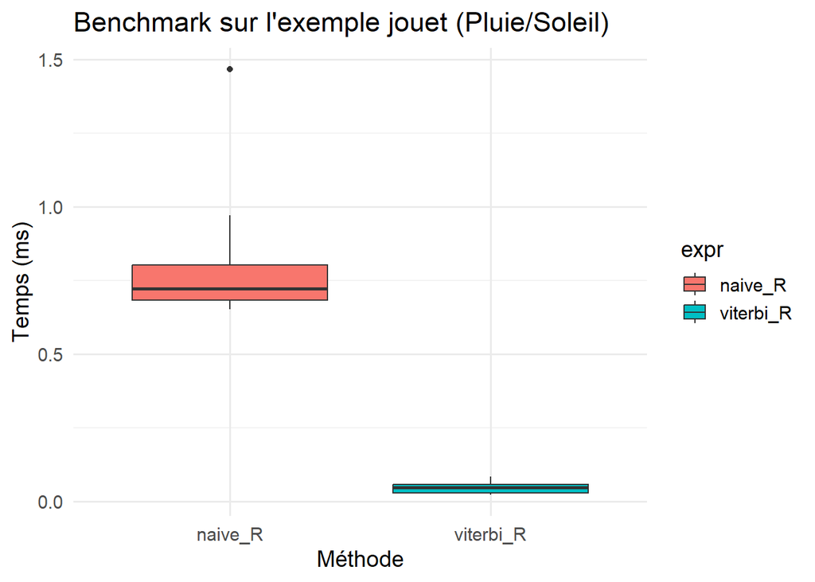

```r
library(microbenchmark)

bm_jouet <- microbenchmark(
  naive_R = trouver_sequence_naive(obs_ps, states_ps, pi_ps, A_ps, B_ps),
  viterbi_R = viterbi(obs_ps, states_ps, pi_ps, A_ps, B_ps),
  times = 10L
)

df_jouet <- as.data.frame(bm_jouet)
ggplot(df_jouet, aes(x = expr, y = time / 1e6, fill = expr)) +
  geom_boxplot() +
  labs(
    title = "Benchmark sur l'exemple jouet (Pluie/Soleil)",
    x = "Méthode",
    y = "Temps (ms)"
  ) +
  theme_minimal(base_size = 14)
```

# Modèle HMM : Rappel

Un modèle de Markov caché est défini par : - Un ensemble d’états cachés $S = \{s_1, s_2, \dots, s_N\}$ - Une séquence d’observations $O = \{o_1, o_2, \dots, o_T\}$ - Une matrice de transition $A$ - Une matrice d’émission $B$ - Un vecteur de probabilités initiales $\pi$

Notre objectif est d’estimer la séquence d’états la plus probable ayant généré la suite d’observations.

# Simulation d’une séquence ADN

```r
set.seed(42)
seq_length <- 500
bases <- c("A", "T", "C", "G")
seq <- paste(sample(bases, seq_length, replace = TRUE), collapse = "")
seq <- DNAString(seq)
states <- rep("N", seq_length)
cds_start <- sample(1:(seq_length - 100), 10, replace = TRUE)
cds_end <- cds_start + 100
for (i in 1:length(cds_start)) {
  states[cds_start[i]:cds_end[i]] <- "C"
}
```

# Estimation des matrices de transition et d’émission

```r
count_CC <- count_CN <- count_NC <- count_NN <- 0
count_A_C <- count_T_C <- count_C_C <- count_G_C <- 0
count_A_N <- count_T_N <- count_C_N <- count_G_N <- 0

for (i in 2:seq_length) {
  if (states[i-1] == "C" && states[i] == "C") count_CC <- count_CC + 1
  else if (states[i-1] == "C") count_CN <- count_CN + 1
  else if (states[i-1] == "N" && states[i] == "C") count_NC <- count_NC + 1
  else count_NN <- count_NN + 1

  base <- substring(as.character(seq), i, i)
  if (states[i] == "C") {
    if (base == "A") count_A_C <- count_A_C + 1
    if (base == "T") count_T_C <- count_T_C + 1
    if (base == "C") count_C_C <- count_C_C + 1
    if (base == "G") count_G_C <- count_G_C + 1
  } else {
    if (base == "A") count_A_N <- count_A_N + 1
    if (base == "T") count_T_N <- count_T_N + 1
    if (base == "C") count_C_N <- count_C_N + 1
    if (base == "G") count_G_N <- count_G_N + 1
  }
}

A <- matrix(c(count_CC, count_CN, count_NC, count_NN), nrow = 2, byrow = TRUE)
A <- A / rowSums(A)
rownames(A) <- colnames(A) <- c("C", "N")

B <- matrix(c(count_A_C, count_T_C, count_C_C, count_G_C,
              count_A_N, count_T_N, count_C_N, count_G_N),
            nrow = 2, byrow = TRUE)
B <- B / rowSums(B)
rownames(B) <- c("C", "N")
colnames(B) <- c("A", "T", "C", "G")

pi <- c(sum(states == "C"), sum(states == "N"))
pi <- pi / sum(pi)
```

# Application des algorithmes sur ADN

```r
obs_small <- sample(1:4, 6, replace = TRUE)
obs_long <- sample(1:4, 50, replace = TRUE)

result_naif <- trouver_sequence_naive_bio(obs_small, c("C", "N"), pi, A, B)
result_viterbi <- viterbi(obs_long, c("C", "N"), pi, A, B)

cat("Résultat Naïf ADN:\n"); print(result_naif)
```

```
## Résultat Naïf ADN:
```

```
## [1] "C" "C" "C" "C" "C" "C"
```

```r
cat("\nRésultat Viterbi ADN:\n"); print(result_viterbi)
```

```
##
## Résultat Viterbi ADN:
```

```
##  [1] "C" "C" "C" "C" "C" "C" "C" "C" "C" "C" "C" "C" "C" "C" "C" "C" "C" "C" "C"
## [20] "C" "C" "C" "C" "C" "C" "C" "C" "C" "C" "C" "C" "C" "C" "C" "C" "C" "C" "C"
## [39] "C" "C" "C" "C" "C" "C" "C" "C" "C" "C" "C" "C"
```

Nous avons mesuré le temps d’exécution des algorithmes sur des séquences d’ADN simulées. Le graphique suivant montre la comparaison :

[figure not shown]

```r
source("C:/Users/gharb/Documents/M2algo_viterbi/viterbiM2/simulations/benchmark_cpp_bio.R")
```

```
## Matrice de transition A :
##             C           N
## C 0.703406814 0.002004008
## N 0.002004008 0.292585170
##
## Matrice d'émission B :
##           A         T         C         G
## C 0.2585227 0.3011364 0.2357955 0.2045455
## N 0.2857143 0.2925170 0.1632653 0.2585034
```

```
## Unit: microseconds
##       expr    min     lq    mean  median     uq     max neval cld
##    naive_R 1737.7 1795.3 3091.94 1880.80 2002.6 13676.8    10  a
##  naive_CPP    1.6    2.8   92.59   12.65   15.0   773.4    10   b
## Unit: microseconds
##         expr   min    lq    mean median    uq     max neval cld
##    viterbi_R 301.0 305.8 1453.63 319.10 335.1 11657.7    10   a
##  viterbi_CPP   2.7   2.8   84.95   7.75  12.0   723.2    10   a
```

# Conclusion